# Exercise_sol

Kim Youngrae

2017 9 17

#### 1. Carefully explain the differences between the KNN classifier and KNN regression methods.

The result of KNN classifier is the class (qualitative), whereas the result of KNN regression is the quantitative value for f(X).

#### 2. Suppose we have a data set with five predictors, $X_1$ = GPA, $X_2$ = IQ, $X_3$ = Gender (1 for Female and 0 for Male), $X_4$ = Interaction between GPA and IQ, and $X_5$ = Interaction between GPA and Gender.

#### The response is starting salary after graduation (in thousands of dollars).

#### Suppose we use least squares to fit the model, and get $\hat{\beta}_0 = 50$, $\hat{\beta}_1 = 20$, $\hat{\beta}_2 = 0.07$, $\hat{\beta}_3 = 35$, $\hat{\beta}_4 = 0.01$, $\hat{\beta}_5=-10$.

$\hat{Salary} = 50 + 20 (GPA) + 0.07 (IQ) + 35 (Gender) + 0.01 (GPA \times IQ) -10 (GPA \times Gender)$

#### (a) Which answer is correct, and why?

1. For a fixed value of IQ and GPA, males earn more on average than females.
2. For a fixed value of IQ and GPA, females earn more on average than males.
3. For a fixed value of IQ and GPA, males earn more on average than females provided that the GPA is high enough.
4. For a fixed value of IQ and GPA, females earn more on average than males provided that the GPA is high enough.

Set $\hspace{2mm} IQ = k_1, GPA =k_2 \hspace{2mm}$, then

$\hat{Salary} \hspace{2mm} | \hspace{2mm} _{IQ=k_1,GPA=k_2} = 50 + 20k_2 +0.07k_1 + 35(Gender) +0.01(k_2 \times k_1) -10 (k_2\times Gender)$

Male (Gender = 0) : $\hat{Salary} \hspace{2mm} | \hspace{2mm} _{IQ=k_1,GPA=k_2} = 50 + 20k_2 +0.07k_1 +0.01(k_2 \times k_1)$

Female (Gender = 1) : $\hat{Salary} \hspace{2mm} | \hspace{2mm} _{IQ=k_1,GPA=k_2} = 50 + 20k_2 +0.07k_1 + 35 +0.01(k_2 \times k_1) -10 (k_2)$

If GPA is high enough, then males earn more than female.

#### (b) Predict the salary of a female with IQ of 110 and a GPA of 4.0.

$\begin{align*}\hat{Salary} \hspace{2mm} | \hspace{2mm} _{IQ=110,GPA=4.0,Gender=1} &= 50 + 20*4 +0.07*110 + 35 +0.01(4 \times 110) -10*(4)\\ &= 137.1\end{align*}$

#### (c) True or false: Since the coefficient for the GPA/IQ interaction term is very small, there is very little evidence of an interaction effect. Justify your answer.

FALSE. P-value of the coefficient detemines significance.

#### 3. Suppose we collect data for a group of students in a statistics class with variables $X_1 =$ hours studied, $X_2 =$ undergrad GPA, and $Y =$ receive an A. We fit a logistic regression and produce estimated coefficient, $\hat{\beta}_0 = -6,\hat{\beta}_1 = 0.05, \hat{\beta}_2 = 1.$

$$p(X) = \frac{\exp{(\beta_0+\beta_1X_1+\beta_2X_2)}}{1+\exp{(\beta_0+\beta_1X_1+\beta_2X_2)}}$$
$$\hat{\beta_0}=-6, \hat{\beta_1}=0.05, \hat{\beta_2}=1$$

#### (a) Estimate the probability that a student who studies for 40 h and has an undergrad GPA of 3.5 gets an A in the class.

In case $(X_1, X_2) = (40,3.5)$,

$\begin{align*} \hat{p(X)} & = \frac{\exp{(\hat{\beta_0}+\hat{\beta_1}X_1+\hat{\beta_2}X_2)}}{1+\exp{(\hat{\beta_0}+\hat{\beta_1}X_1+\hat{\beta_2}X_2)}} \\ & = \frac{\exp{(-6+0.05*40+1*3.5)}}{1+\exp{(-6+0.05*40+1*3.5)}} \\ & = \frac{exp(-0.5)}{1+exp(-0.5)} \\ & = 37.75\% \end{align*}$

#### (b) How many hours would the student in part (a) need to study to have a 50% chance of getting an A in the class?

When $\hat{p(X)} = 0.5, X_2 = 3.5, X_1 = ?$

$\begin{align*} \hat{p(X)} & = \frac{\exp{(\hat{\beta_0}+\hat{\beta_1}X_1+\hat{\beta_2}X_2)}}{1+\exp{(\hat{\beta_0}+\hat{\beta_1}X_1+\hat{\beta_2}X_2)}} \\ \Leftrightarrow & 0.5 = \frac{\exp{(-6+X_1*40+1*3.5)}}{1+\exp{(-6+X_1*40+1*3.5)}} \\ \Leftrightarrow & 0.5 = 0.5 exp(-2.5+0.05X_1) \\ \Leftrightarrow & X_1 = 2.5/ 0.05 = 50\end{align*}$

#### 4. This problem has to do with odds.

#### (a) On average, what fraction of people with an odds of 0.37 of defaulting on their credit card payment will in fact default?

Let $p$ be the probability to default.

$$\begin{align*} \frac{p}{1-p} & = 0.37 \\ 0.37 (1-p) & = p \\ 1.37p & = 0.37 \\ p & \sim 0.27 \end{align*}$$

So, 27%.

#### (b) Suppose that an individual has a 16% chance of defaulting on her credit card payment. What are the odds that she will default?

$$\text{odds} = \frac{p}{1-p} = \frac{0.16}{1-0.16} \sim 0.19$$

#### 5. We perform best subset, forward stepwise, and backward stepwise selection on a single data set. For each approach, we obtain $p+1$ models, containing $0, 1, 2, . . . , p$ predictors. Explain your answers:

#### (a) Which of the three models with k predictors has the smallest training RSS?

Best subset selection has the smallest training RSS because the other two methods depend on first pick.

#### (b) Which of the three models with k predictors has the smallest test RSS?

Best subset selection may have the smallest test RSS because it considers more models then the other methods.

#### (c) True or False:

1. The predictors in the k-variable model identified by forward stepwise are a subset of the predictors in the (k+1)-variable model identified by forward stepwise selection.

True.

2. The predictors in the k-variable model identified by back- ward stepwise are a subset of the predictors in the (k + 1)- variable model identified by backward stepwise selection.

True.

3. The predictors in the k-variable model identified by back- ward stepwise are a subset of the predictors in the (k + 1)- variable model identified by forward stepwise selection.

False.

4. The predictors in the k-variable model identified by forward stepwise are a subset of the predictors in the (k+1)-variable model identified by backward stepwise selection.

False.

22. The predictors in the k-variable model identified by best subset are a subset of the predictors in the (k + 1)-variable model identified by best subset selection.

False.

#### 6. Suppose we estimate the regression coefficients in a linear regression model by minimizing

$$\sum_{i=1}^n(y_i-\beta_0-\sum_{j=1}^p\beta_j x_{ij}) \textrm{ subject to } \sum_{j=1}^p|\beta_j|\leq s$$

#### for a particular value of $s$. For parts (a) through (e), indicate which of i. through v. is correct. Justify your answer.

#### (a) As we increase s from 0, the training RSS will:

1. Increase initially, and then eventually start decreasing in an inverted U shape.
2. Decrease initially, and then eventually start increasing in a U shape.
3. Steadily increase.
4. Steadily decrease.
5. Remain constant.
6. Steadily decrease.

As we increase s from 0, $\beta$ increase from 0 to LSE. When all $\beta$s are zero, training RSS is maximum.

#### (b) Repeat (a) for test RSS.

2. Decrease initially, and then eventually start increasing in a U shape.

Similarly to training RSS, test RSS is big when all $\beta$s are zero. As we increase s, test RSS goes down. But as $\beta$ approaches LSE, it starts overftting, increasing test RSS.

#### (c) Repeat (a) for variance.

3. Steadily increase.

When $s=0$, there is no non-zero $\beta$. So the model predicts a constant and has no variance. As s increase, $\beta$ will be in the model. Thus variance increase.

#### (d) Repeat (a) for (squared) bias.

4. Steadily decrease.

When $s=0$, all $\beta$ are zero. So predicted value is far from the actual value. Thus bias is high. As s increase, $\beta$ goes to fit data better. The bias might decrease.

#### (e) Repeat (a) for the irreducible error.

22. Remain constant.

Irreducible error is model independent.

#### 7. Suppose we estimate the regression coefficients in a linear regression model by minimizing

$$\sum_{i=1}^n)y_i-\beta_0-\sum_{j=1}^p\beta_j x_{ij}) + \lambda \sum_{j=1}^p \beta_j^2$$

#### for a particular value of $\lambda$. For parts (a) through (e), indicate which

of i. through v. is correct. Justify your answer.

#### (a) As we increase $\lambda$ from 0, the training RSS will:

1. Increase initially, and then eventually start decreasing in an inverted U shape.
2. Decrease initially, and then eventually start increasing in a U shape.
3. Steadily increase.
4. Steadily decrease.
5. Remain constant.
6. Steadily increase.

As we increase $\lambda$, all $\beta$s decrease from LSE to 0.

#### (b) Repeat (a) for test RSS.

2. Decrease initially, and then eventually start increasing in a U shape.

When $\lambda=0$, $\beta$ is LSE. As $\lambda$ increase, $\beta$ decrease to 0 reducing the overfitting. But when $\lambda$ is too big, $\beta$ is too small. It increase test RSS.

#### (c) Repeat (a) for variance.

4. Steadily decreases.

When $\lambda=0$, $\beta$ is LSE and it is the best fit for training data. So variance is big. As $\lambda$ increase, the variance goes down.

#### (d) Repeat (a) for (squared) bias.

3. Steadily increases.

When $\lambda=0$, $\beta$ is LSE. So it has the least bias. As $\lambda$ increase, $\beta$ moves to 0. Thus bias increase.

#### (e) Repeat (a) for the irreducible error.

22. Remain constant.

Irreducible error is model independent.

#### 10. Suppose we produce ten bootstrapped samples from a data set containing red and green classes. We then apply a classification tree to each bootstrapped sample and, for a specific value of $X$, produce 10 estimates of $P(Class is Red|X)$:

$$0.1, 0.15, 0.2, 0.2, 0.55, 0.6, 0.6, 0.65, 0.7, \text{ and } 0.75.$$
#### There are two common ways to combine these results together into a single class prediction. One is the majority vote approach discussed in this chapter. The second approach is to classify based on the average probability. In this example, what is the final classification under each of these two approaches?

Majority vote approach ;

The number of estimates > 0.5 is bigger than < 0.5. : RED.

Average approach ;

GREEN.

#### 12. Here we explore the maximal margin classifier on a toy data set.

#### (a) We are given $n = 7$ observations in $p = 2$ dimensions. For each observation, there is an associated class label.

[output not shown]

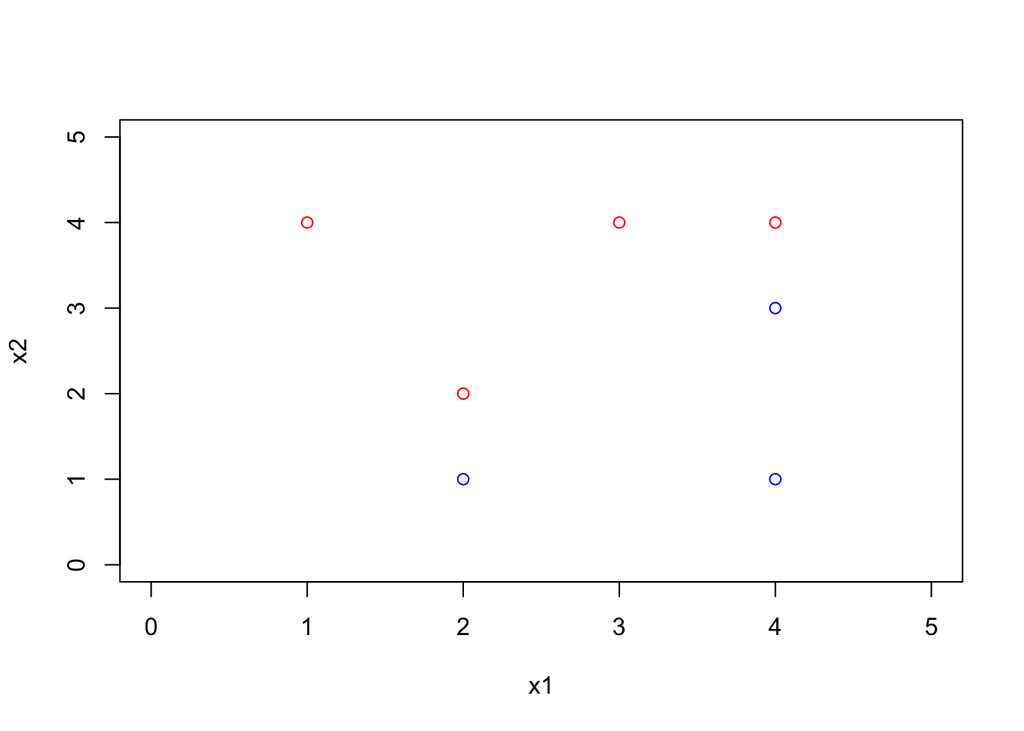

```r
x1<-c(3,2,4,1,2,4,4); x2<-c(4,2,4,4,1,3,1); y<-c("Red","Red","Red","Red","Blue","Blue","Blue");
plot(x1,x2,col=y,xlim=c(0,5),ylim=c(0,5))
```

#### (b) Sketch the optimal separating hyperplane, and provide the equa- tion for this hyperplane (of the form (9.1)).

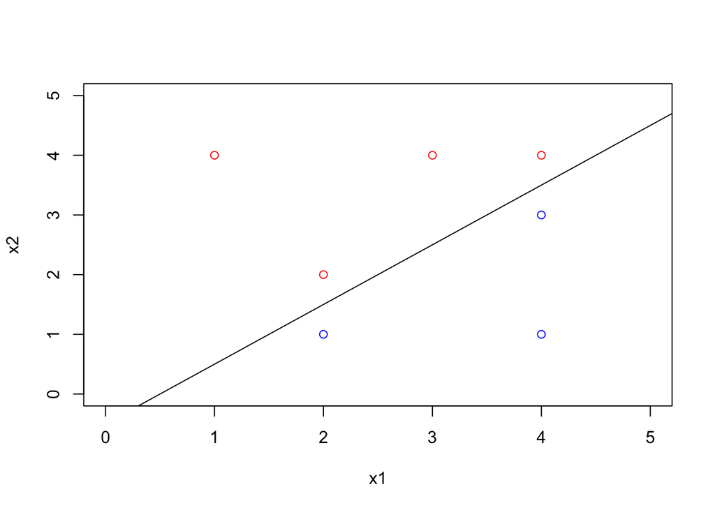

```r
plot(x1,x2,col=y,xlim=c(0,5),ylim=c(0,5))
abline(-0.5,1)
```

#### (c) Describe the classification rule for the maximal margin classifier. It should be something along the lines of ?Classify to Red if $\beta_0+\beta_1X_1+\beta_2X_2>0$, and classify to Blue otherwise.? Provide the values for $\beta_0,\beta_1,$ and $\beta_2$.

Classification rule ; $0.5-X1+X2>0$

$\beta_0 = 0.5, \beta_1 = -1, \beta_2 = 1$

#### (d) On your sketch, indicate the margin for the maximal margin hyperplane.

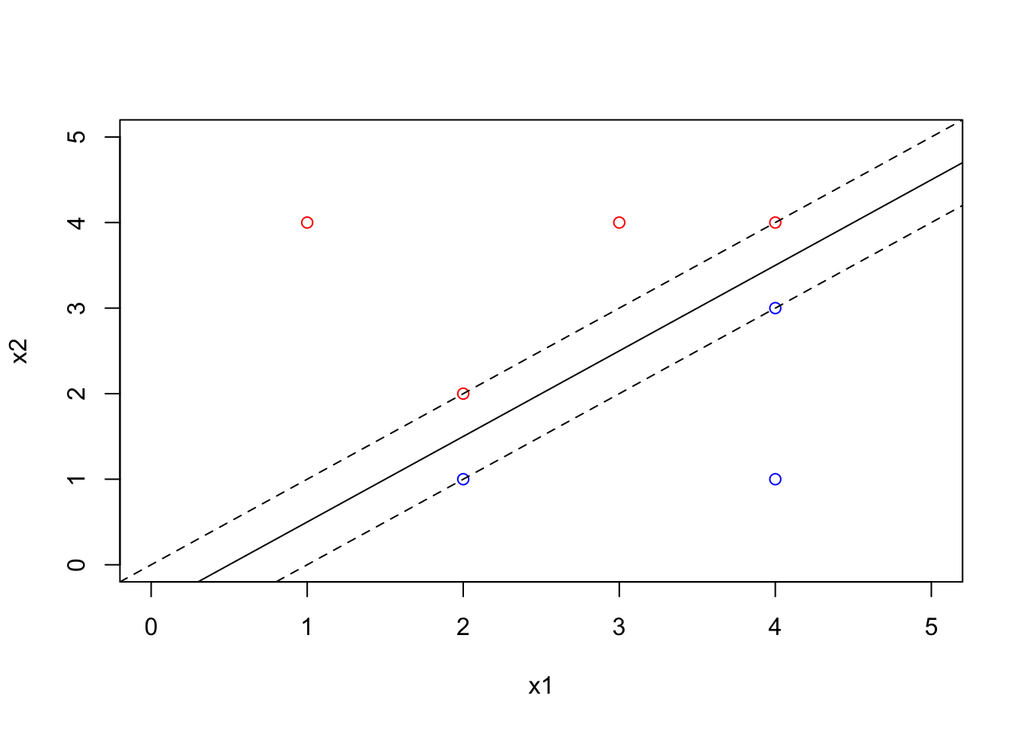

```r
plot(x1,x2,col=y,xlim=c(0,5),ylim=c(0,5))
abline(-0.5,1)
abline(0,1,lty=2); abline(-1,1,lty=2)
```

#### (e) Indicate the support vectors for the maximal margin classifier.

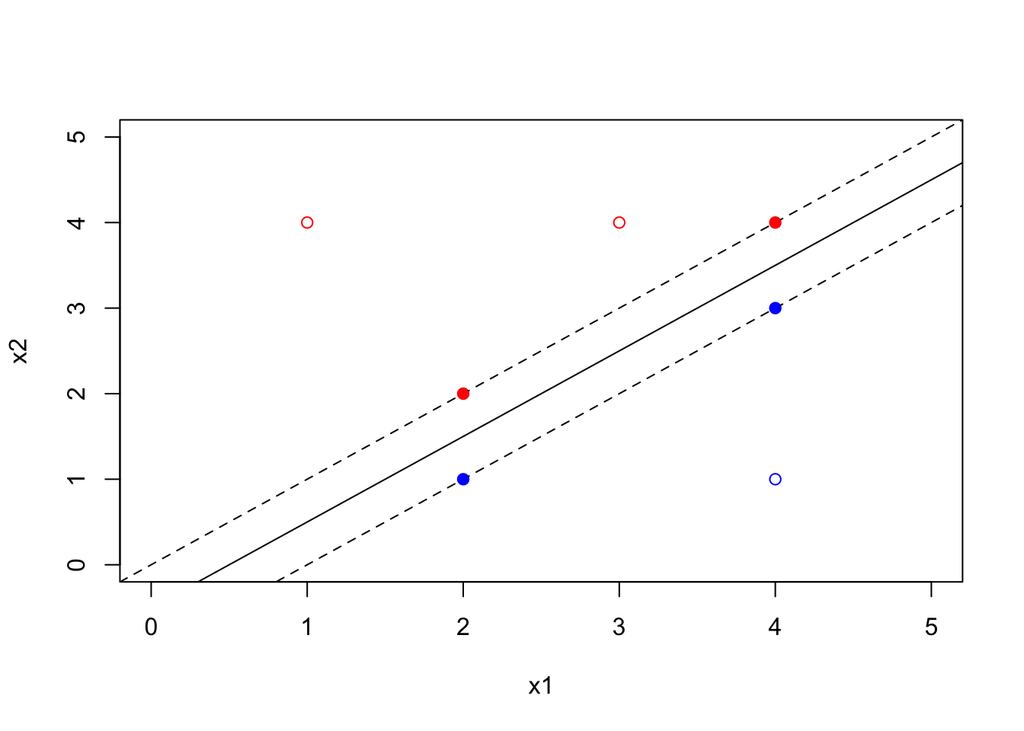

```r
plot(x1,x2,col=y,xlim=c(0,5),ylim=c(0,5))
abline(-0.5,1)
abline(0,1,lty=2); abline(-1,1,lty=2)
points(x1[c(5,6,2,3)],x2[c(5,6,2,3)],col=y[c(5,6,2,3)],pch=16)
```

#### (f) Argue that a slight movement of the seventh observation would not affect the maximal margin hyperplane.

Since the seventh observation is not support vector(outside of the margin), it cannot affect the maximal margin hyperplane.

#### (g) Sketch a hyperplane that is not the optimal separating hyper- plane, and provide the equation for this hyperplane.

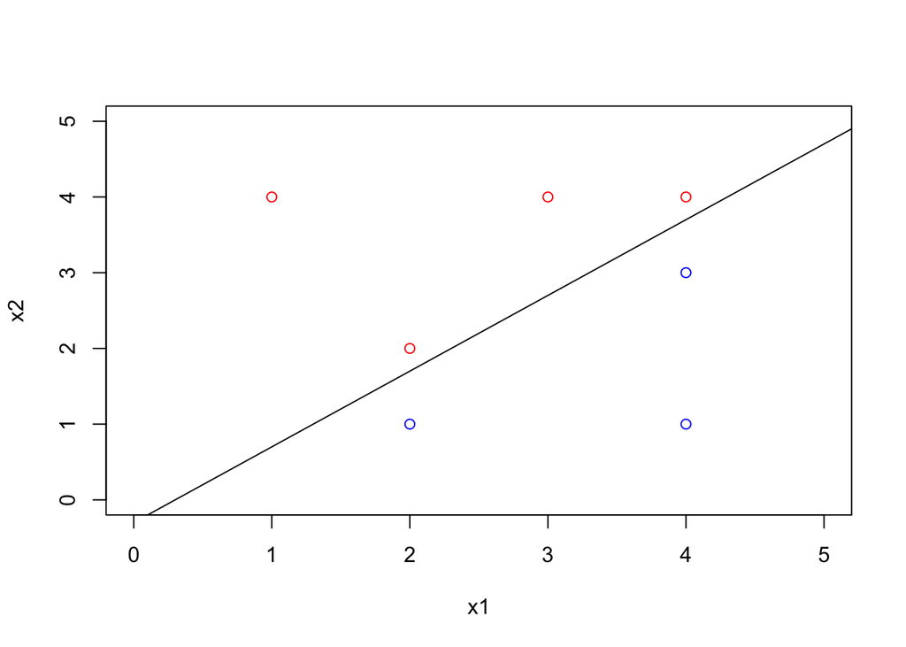

```r
plot(x1,x2,col=y,xlim=c(0,5),ylim=c(0,5))
abline(-0.3,1)
```

Classification rule ; $0.3-X1+X2>0$

#### (h) Draw an additional observation on the plot so that the two classes are no longer separable by a hyperplane.

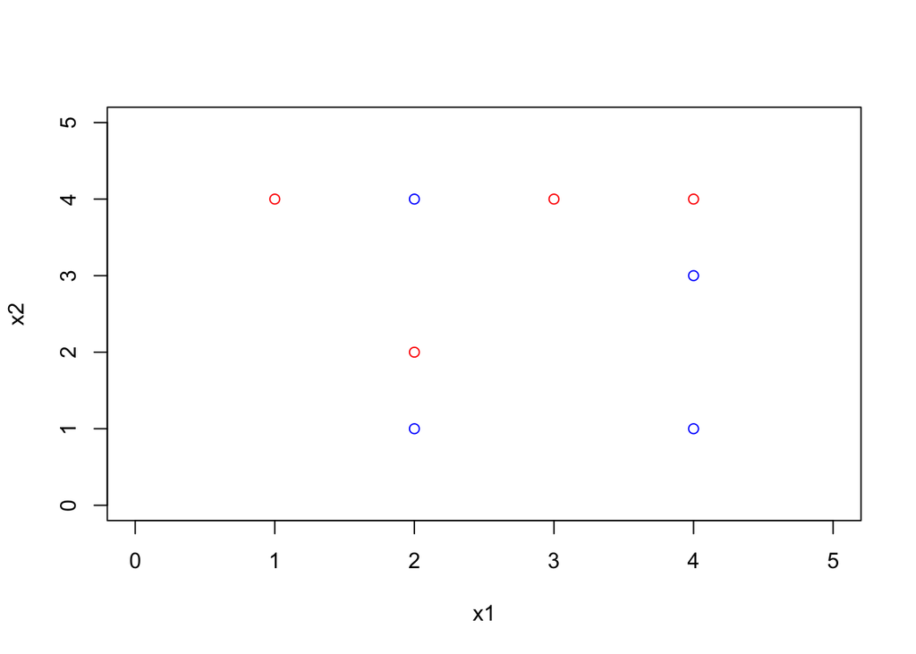

```r
plot(x1,x2,col=y,xlim=c(0,5),ylim=c(0,5))
points(2,4,col="Blue")
```

#### (a) Plot the observation.

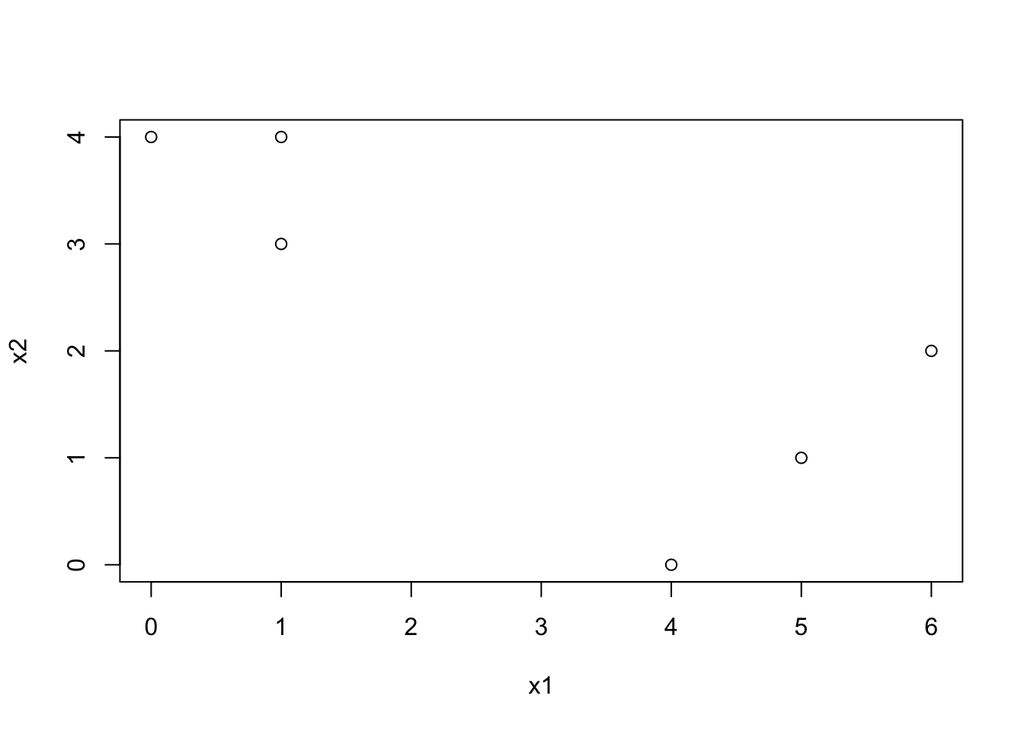

```r
x1<-c(1,1,0,5,6,4); x2<-c(4,3,4,1,2,0);
plot(x1,x2)
```

#### (b) Randomly assign a cluster label to each observation. You can use the sample() command in R to do this. Report the cluster labels for each observation.

```r
set.seed(170918)
labels<-sample(2,6,replace=T)
labels
```

```
## [1] 1 2 2 2 1 2
```

#### (c) Compute the centroid for each cluster.

```r
x<-cbind(x1,x2)
c1<-colMeans(x[labels==1,])
c2<-colMeans(x[labels==2,])
```

#### (d) Assign each observation to the centroid to which it is closest, in terms of Euclidean distance. Report the cluster labels for each observation.

```r
new.labels<-rep(0,nrow(x))
for(i in 1:nrow(x)){
  if(sum((x[i]-c1)^2)<sum((x[i]-c2)^2)){
    new.labels[i]<-1
  }else{
    new.labels[i]<-2
  }
}
new.labels
```

```
## [1] 2 2 2 1 1 1
```

#### (e) Repeat (c) and (d) until the answers obtained stop changing.

```r
old.labels=rep(-1,6)
while(sum(old.labels!=labels)!=0){
  old.labels<-labels
  c1<-colMeans(x[labels==1,])
  c2<-colMeans(x[labels==2,])
  labels<-rep(0,nrow(x))
  for(i in 1:nrow(x)){
    if(sum((x[i]-c1)^2)<sum((x[i]-c2)^2)){
      labels[i]<-1
    }else{
      labels[i]<-2
    }
  }
}
labels
```

```
## [1] 2 2 2 1 1 1
```

#### (f) In your plot from (a), color the observations according to the cluster labels obtained.

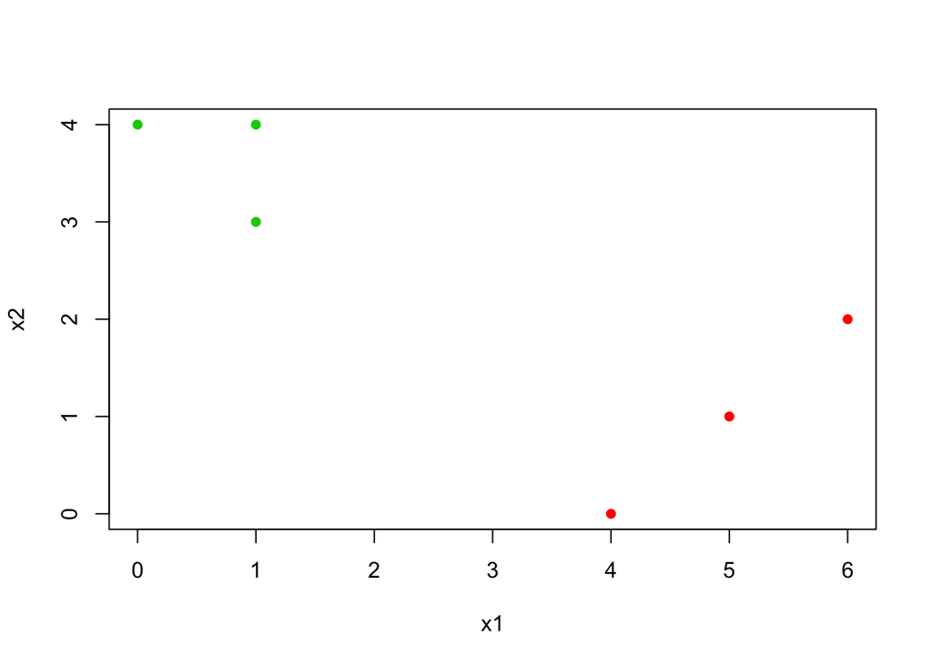

```r
x1<-c(1,1,0,5,6,4); x2<-c(4,3,4,1,2,0);
plot(x1,x2,col=labels+1,pch=16)
```